# Elementary Statistics using Excel

Nov 15, 2018

## Chapter 6 Section 1 Objectives

### The Standard Normal Distribution

- Describe the characteristics of a standard normal distribution
- Find the probability of some range of z-values in a standard normal distribution
- Find z scores to regions under the curve representing a standard normal distribution

## Definitions 6.1

- **Normal distribution** - a continuous random variable has a distribution with a graph that is symmetric and bell-shaped.
- **Uniform distribution** - a continuous random variable has an even spread over a range of possibilities.
- **Density Curve** - A graph of any continuous probability distribution. It must have a total area under the curve is exactly 1.
- **Standard Normal Distribution** - a normal distribution with the parameters of \(\mu = 0\) and \(\sigma = 1\). The total area under the curve is equal to 1.
- **Critical Value** - a z-score that is on the borderline that separates the z-scores that are significantly high or low

## Normal Distribution

\[ y = \frac{e^{-\frac{1}{2}(\frac{x-\mu}{\sigma})^2}}{\sigma\sqrt{2\pi}}\]

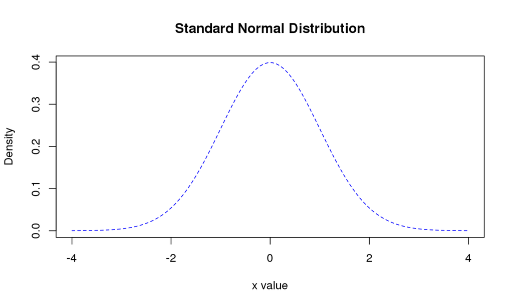

## Uniform Distribution

- Whats the area under the curve?

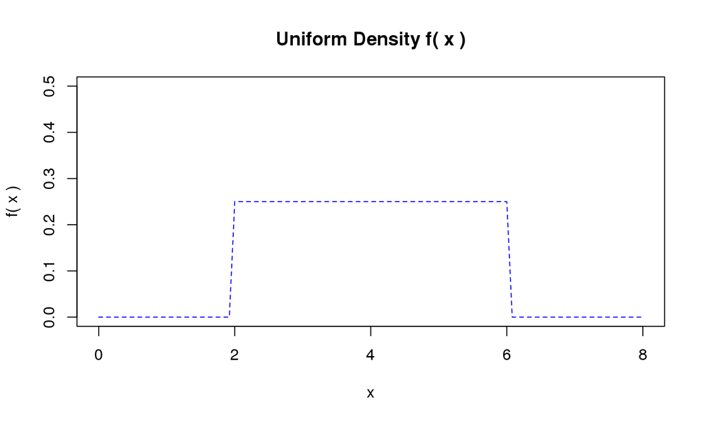

## Finding Probabilities when given a *z*-score

- Table A-2 in your book.
- Each value represents the area under the curve to the left of the *z*-score
- Using Excel
  - use **NORM.DIST**
  - =**NORM.DIST**(x, mean, standard_deviation, cumulative)
  - x is the *z*-score
  - mean (for standard normal the mean is 0)
  - standard deviation (for standard normal the standard deviation is 1)
  - cumulative tells if you wan the area to the left up to the *z*-score1

## An Example

- A randomly selected adult undergoes a bone density test. Find the probability that this person has a bone density test score of less than 1.73. The test scores for bone density have a mean of 0 and a standard deviation of 1.
  - What do you get from Table A-2?
  - What do you get from excel?
  - Are they similar?
  - What about a score greater than 1.73?

## Finding the area between two values

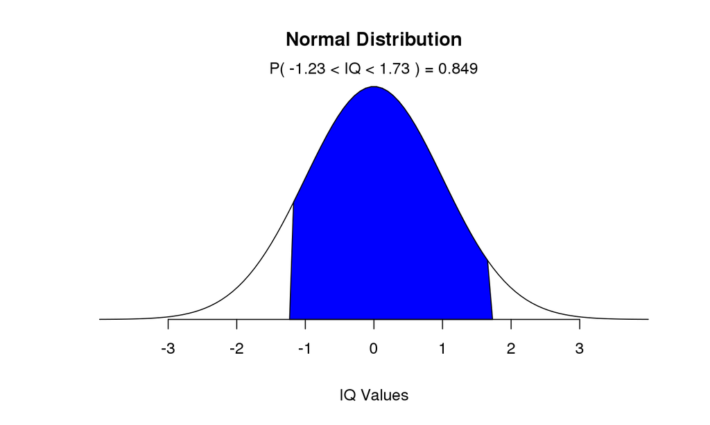

## Finding a *z*-score from known area

- Use table A-2
- Use Excel NORM.INV
  - =NORM.INV(p, mean, standard deviation)
  - p is the probability area
  - mean use 0 if you are looking for a *z*-score
  - standard deviation use 1 if you are looking for a *z*-score

## Chapter 6 Section 2 Objectives

### Real Applications of Normal Distributions

- Develop the ability to describe a normal distribution
- Find the probability of some range of values in a normal distribution
- Find x scores corresponding to regions under the curve representing a normal distribution

## *z*-score formula

\[ z = \frac{x-\mu}{\sigma}\]

- The *z*-score formula can allow you to use the table A-2 on non-standard normal distributions.
- The mean body temperature is 98.6 degrees Fahrenheit with a standard deviation of 0.73 degree Fahrenheit according to the University of Wisconson - madison.
- What is the probability that a person has a body temperature of 97.2 degrees Fahrenheit?
  - Table A-2?
  - Excel?

## Airforce Height of pilots

- In the airfore pilots are required to be 64 to 77 in. and women have an average height of 63.7 in. with a standard deviation of 2.9 in.. What percent of women meet the height requirement?

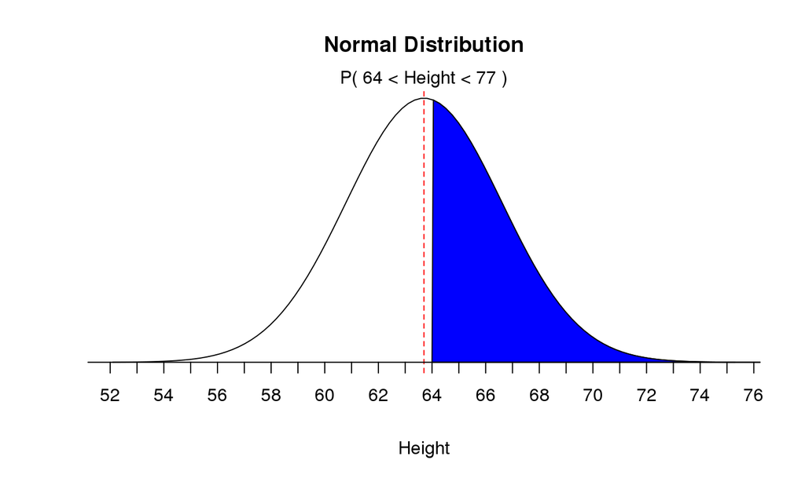

## Chapter 6 Section 3 Objectives

### Sampling Distributions and Estimators

- Develop the ability to describe a sampling distribution of a statistic
- Determine whether a statistic serves as a good estimator of the corresponding population parameter

## Definitions 6.3

- **Sampling distribution of a statistic** - The distribution o fall values of the statistic when all possible samples of the same size *n* are taken from a the same population.
- **Sampling distribution of a sample proportion** - The distribution of sample proportions with all samples having the same sample size *n* taken from the same population.
- **Sampling distribution of the sample mean** - The distribution of all possible sample means with all samples having the same sample size *n* taken from the same population.
- **Sampling distribution of the sample variance** - The distribution of all possible sample variances with all samples having the same sample size *n* taken from the same population.
- **Estimator** - Statistic used to estimate a population parameter
- **Unbiased estimator** - Statistic that targets the value of the corresponding population parameter in the sense that the sampling distribution of the statistic has a mean that is equal to the correspond population parameter.

## Behavior of sample proportions

- Sample proportions tend to be normally dsitributed
- The mean of sample proportions is the same as the population proportion

## Behavior of sample means

- Sample means tend to be normally distributed
- Sample means target the population mean

## Behavior of sample variances

- Sample variances tend to be skewed right
- Sample variances target teh population variance

## Unbiased vs. Biased estimators

| Unbiased | Biased |
| --- | --- |
| Proportion (\(\hat{p}\)) | Median |
| Mean (\(\bar{x}\)) | Range |
| Variance (\(s^2\)) | Standard Deviation |
| *Target the population parmeter* | *Does not target population parameter* |